# Preprocessing TeDDi Sample

Chris Bentz

06.03.2025

# Description

This file enables preprocessing of the TeDDi sample natural language text material (Moran et al., 2022). This is used as a sample to compare against the sign codings for proto-cuneiform and paleolithic sign sequences. Dumps of the TeDDi sample can be downloaded from https://drive.switch.ch/index.php/s/MJv7xFkzqlzFn0y. Note that the sample of TeDDi lines was here produced by using the follwing Perl commands in the directory where the lines.csv file is stored:

head -1 line.csv > line_sample.csv

perl -ne ‘print if (rand() < .01)’ line.csv >> line_sample.csv

## Preprocessing of Raw Text Lines

The text lines are here further cleaned, since there is some unwanted noise in the character strings. In particular, we use the regex “[[:punct:]]” to remove punctuation from all text lines. While it can be argued that punctuation belongs to writing, the problem is that some text lines consist of only punctuation, e.g. “** *” or a series of symbols for musical notes which are arguably not genuine writing (i.e. not representing speech sounds – not even in an indirect way).

We also use the regex “[!-~]” to remove ASCII characters (see table below) from number 33 (exclamation mark) to 126 (tilde) from *non-Latin* scripts. This is because there is – mainly English – contamination of texts in other languages and writing systems (e.g. Mandarin Chinese, Korean). Note that this also removes some of the punctuation in the non-Latin scripts.

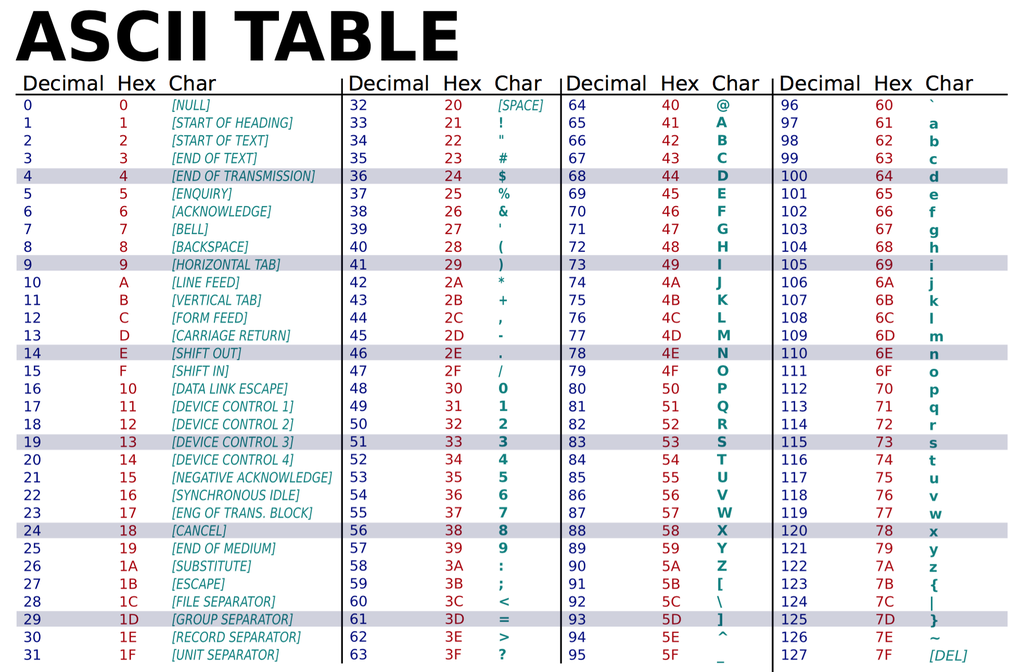

Figure. ASCII table from WikiCommons.

```r
knitr::include_graphics("~/Github/PaleoSigns/figures_external/ASCII-Table.png")
```

## Chinese characters to strokes

We also transliterate Chinese characters into individual strokes using the mapping given by Wang et al. (2022) via https: //github.com/zjwang21/StrokeNet. The original file name with the mappings is zh2letter.txt. This provides a mapping from Chinese characters to individual component strokes given as Latin characters (for ease of further processing). See also figure below.

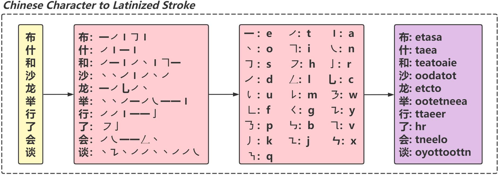

Figure. Mapping of Chinese characters to strokes. This is part of Figure 1 in Wang et al. (2022).

```r
knitr::include_graphics("~/Github/PaleoSigns/figures_external/wang.jpg")
```

# Session Info

Give the session info (reduced).

```
## [1] "R version 4.3.3 (2024-02-29)"
```

```
## [1] "x86_64-pc-linux-gnu"
```

# Load libraries

If the libraries are not installed yet, you need to install them using, for example, the command: install.packages(“ggplot2”).

```r
library(dplyr)
```

Give the package versions.

```
## [1] "1.1.4"
```

# Load the TeDDi data

```r
# load data from TeDDi dumps
line.data <- read.csv(
  "~/Github/PaleoSigns/data/TeDDi/line_sample.csv")
file.data <- read.csv("~/Github/PaleoSigns/data/TeDDi/file.csv")
# merge the files
teddi.data <- merge(line.data, file.data, by.x = "file_id", by.y = "id")
```

# Further Sampling

Sample a given number of lines randomly as a comparative sample.

```r
set.seed(15022018)
teddi.sample <-sample_n(teddi.data, 1000)
```

# Data Cleaning

Remove punctuation for all text lines, as well as ASCII Characters from non-Latin writing systems (this is the most common type of noise in this data).

```r
# remove punctuation from all text lines
teddi.sample$text <- gsub("[[:punct:]]", '', teddi.sample$text)
# remove ASCII characters from non-Latin scripts
# the regex "[!-~]" matches ASCII characters (except white spaces)
teddi.sample[teddi.sample$writing_system != "Latn", ]$text <-
  gsub("[!-~]", '', teddi.sample[teddi.sample$writing_system != "Latn", ]$text)
```

# Transliterate Chinese Characters to Strokes

## Read file with strokes per character

Transliterate Chinese characters to strings of strokes represented by Latin characters.

```r
# load stroke transliteration list
stroke.file = "~/Github/PaleoSigns/data/TeDDi/zh2letter.txt"
stroke.df <- read.table("~/Github/PaleoSigns/data/TeDDi/zh2letter.txt", sep = " ")
# add column names
colnames(stroke.df) <- c("chars","strokes")
# give beginning of signlist
# head(stroke.df)
```

## Replace Chinese characters by strokes

```r
# select only Hanzi simplified script (ISO code Hans)
hans.data <- teddi.sample[teddi.sample$writing_system == "Hans", ]
# split into individual characters (list by text line)
hans.list <- strsplit(hans.data$text, split = "")
# head(hans.list)
# replace characters with stroke transliterations for each string in list
for (i in 1:length(hans.list)){
  # remove remaining white spaces
  hans.list[[i]] <- hans.list[[i]][hans.list[[i]] != " "]
  hans.list[[i]] <- paste(with(stroke.df, strokes[match(hans.list[[i]], chars)]), collapse = " ")
}
# head(hans.list)
# unlist and replace original text column in cmn dataframe
hans.data$text <- unlist(hans.list)
# add comment on stroke transliteration in column "comments"
hans.data$writing_system <- rep("Hans (strokes)", nrow(hans.data))
# add cmn data with strokes to overall data frame
teddi.sample.modified <- rbind(teddi.sample, hans.data)
```

# Final Preprocessing

Trim white spaces at beginning and end of texts sequences, remove empty text rows (only consisting of white spaces), as well as very short text lines as these can cause NAs in the later calculations. This is the same for other sequences, i.e. paleolithic and proto-cuneiform.

```r
teddi.clean <- teddi.sample.modified[teddi.sample.modified$text != "", ]
teddi.clean$text <- trimws(teddi.clean$text)
teddi.clean <- teddi.clean[nchar(teddi.clean$text) > 1, ]
```

# Simple Stats

Some simple stats of the textual data here sampled from TeDDi.

```r
# lines of text
nrow(teddi.clean)
```

```
## [1] 1040
```

```r
# unique ISO codes (i.e. languages)
unique(teddi.clean$iso639_3)
```

```
##  [1] "rus" "ell" "kat" "fra" "tur" "jpn" "fin" "deu" "pes" "heb" "cmn" "gug"
## [13] "tha" "spa" "ind" "eng" "mya" "vie" "kor" "eus" "arz" "hin" "yor" "tgl"
## [25] "khk" "cha" "ram" "plt" "dgz" "hae" "jac" "apu" "amp"
```

```r
# writing systems
unique(teddi.clean$writing_system)
```

```
##  [1] "Cyrl"           "Grek"           "Geor"           "Latn"
##  [5] "Jpan"           "Arab"           "Hebr"           "Hans"
##  [9] "Thai"           "Mymr"           "Kore"           "Deva"
## [13] "Hang"           "Hans (strokes)"
```

Write to file.

```r
# order the columns for convenience
teddi.clean <- teddi.clean[order(teddi.clean$language_name_glotto), ]
# write to file
write.csv(teddi.clean,
          file = "~/Github/PaleoSigns/data/TeDDi/final_sample.csv", row.names = F)
```

# Package References

```
## Wickham H, François R, Henry L, Müller K, Vaughan D (2023). _dplyr: A
## Grammar of Data Manipulation_. R package version 1.1.4,
## <https://CRAN.R-project.org/package=dplyr>.
```

# Literature References

Moran, S., Bentz, C., Gutierrez-Vasques, X., Pelloni, O., & Samardzic, T. (2022). TeDDi sample: text data diversity sample for language comparison and multilingual NLP. In Proceedings of the Thirteenth Language Resources and Evaluation Conference (pp. 1150-1158).

Wang, Z., Liu, X., & Zhang, M. (2022). Breaking the representation bottleneck of Chinese characters: Neural machine translation with stroke sequence modeling. arXiv preprint arXiv:2211.12781.